# Payco Payments Data Science Dashboard 2021-2025

# payco payments data science

Synthetic C2C marketplace data, 2021-2025 | 328,346 checkouts | €12.5M paid volume | Models tested on 2025

## 1. Payments overview

How much money moves through Payco, how often payments succeed, and the three targets the models predict.

Checkouts 2025

90,822

+21.4% vs 2024

Paid volume

€3.9M

+32.2% vs 2024

Attempt approval rate

89.8%

+0.8 pp vs 2024

Fraud rate

0.68%

+0.3 pp vs 2024

Chargeback rate

0.47%

+0.1 pp vs 2024

### Yearly payment KPIs

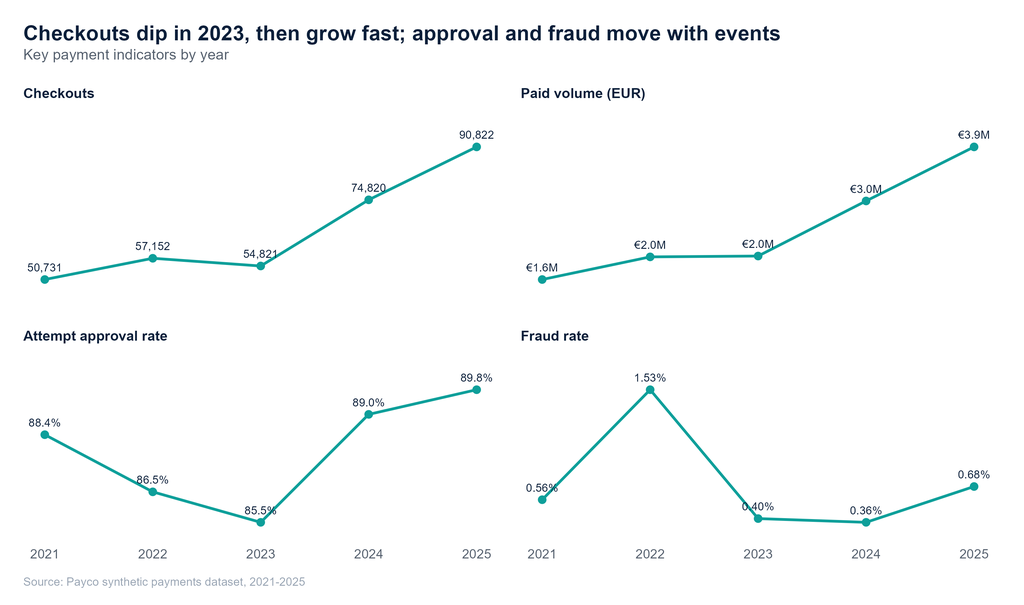

**Results.** Paid volume grew from €1.6M in 2021 to €3.9M in 2025, a compound growth rate of 25.5% a year. The approval rate was lowest in 2023 (85.5%), when stricter 3DS checks and a PSP outage added friction, and highest in 2025 (89.8%). Fraud peaked in 2022 at 1.53% of paid transactions during the account takeover wave.

### Payment method mix

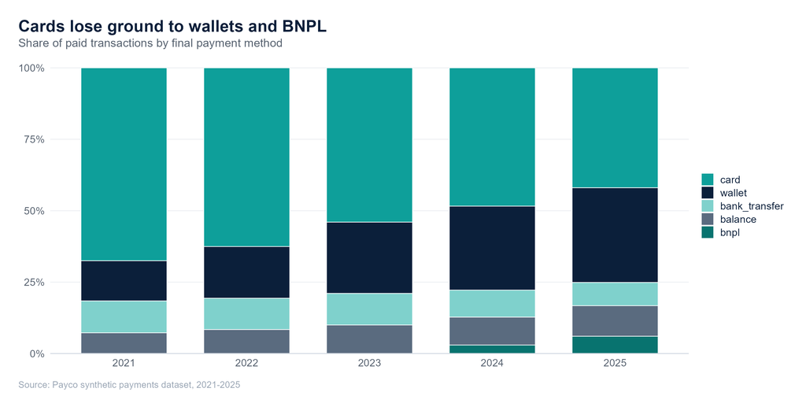

**Results.** Cards fell from 67.5% of paid transactions in 2021 to 42.0% in 2025, while wallets rose from 14.0% to 33.1%. BNPL launched in 2024 and reached 6.1% in 2025. A fraud model trained only on card-heavy years must cope with this shift.

### The three modelling targets

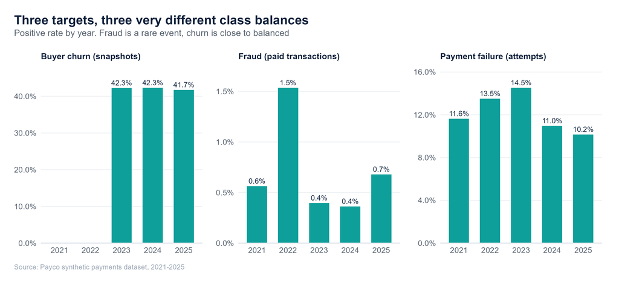

**Results.** Fraud is rare: 0.69% of paid transactions, about one fraud for every 144 legitimate ones, so accuracy is useless as a metric and PR-AUC is used instead. Payment failure affects 11.9% of attempts, and 42% of active buyers make no purchase in the following 180 days.

**Method.** All models use a time-based split: train on earlier periods, test on the latest one, never a random split. Features only use information available at the moment of prediction (for example, accounts seen on a device *before* the checkout). Columns known only afterwards, such as refunds, chargebacks, account status and the 3DS result for failure prediction, are excluded.

## 2. Fraud patterns

When fraud happens, where it hides, and which signals separate it from normal buying.

### Fraud rate over time

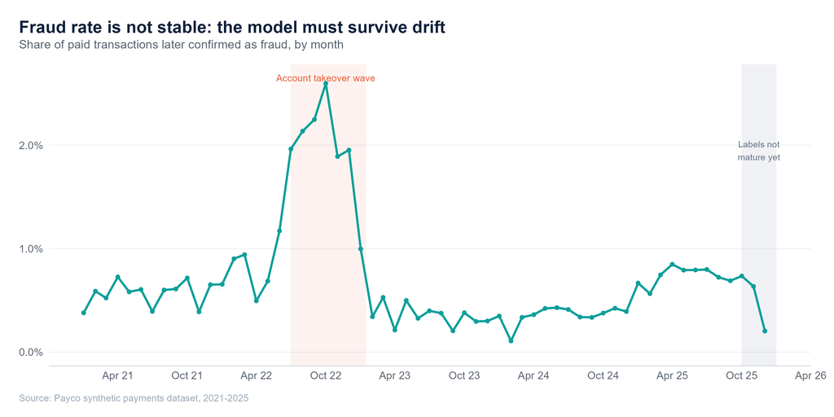

**Results.** In 2021 about 0.56% of paid transactions were fraud. The account takeover wave pushed the monthly rate to 2.60% in October 2022, about 4.6 times the 2021 level. The drop in the last months of 2025 is not good news: those labels are not mature yet, because chargebacks and reviews take weeks. These months are excluded from model evaluation.

### Fraud rate by risk signal

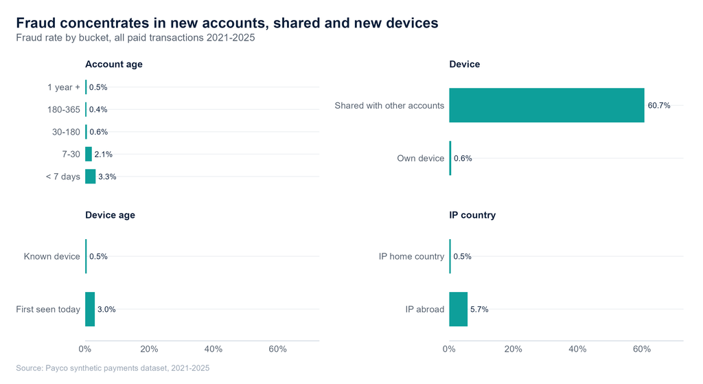

**Results.** Accounts less than a week old have a fraud rate of 3.3%, against 0.46% for accounts older than a year. Devices already used by other accounts are a strong ring signal: 60.7% fraud against 0.61% on a buyer’s own device. These features are built without look-ahead, counting only accounts seen on the device before each checkout.

### Fraud by payment method

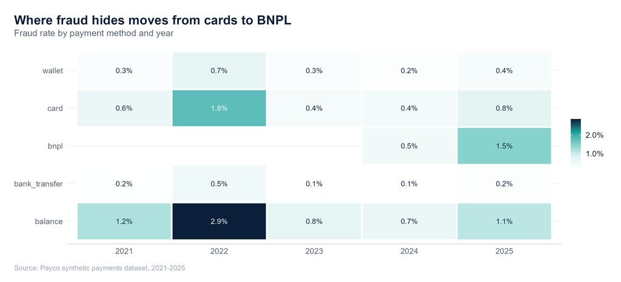

**Results.** In 2022 card fraud reached 1.76%. By 2025 the BNPL fraud rate (1.46%) is above the card rate (0.80%), as fraudsters follow the newest and least defended payment method. Payment method has to be in the model, and its effect is not constant over time.

### Single-feature signal strength

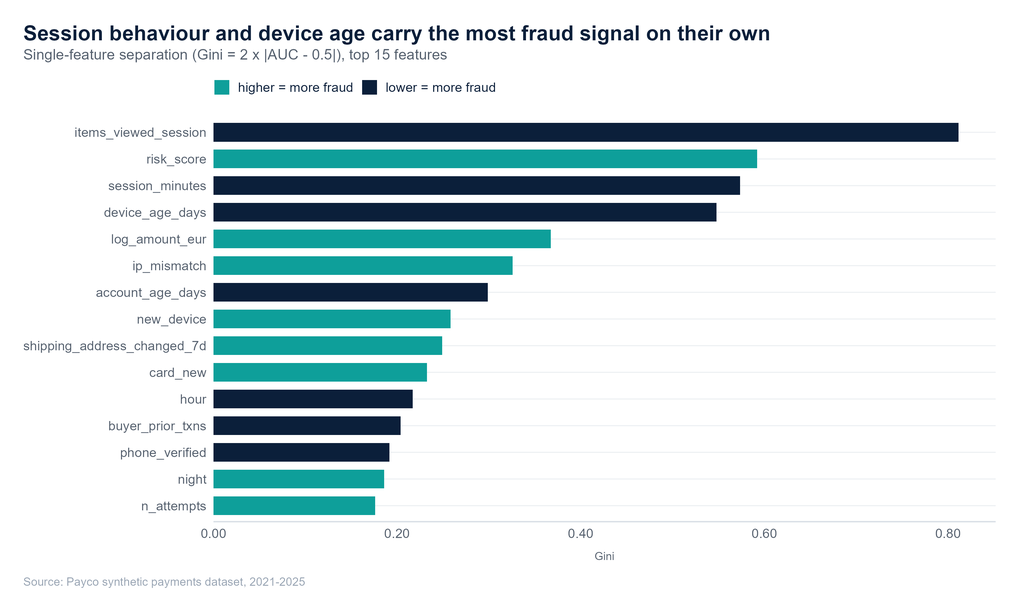

**Results.** On their own, items viewed in the session, legacy risk score and session length separate fraud best (Gini 0.81, 0.59 and 0.57). Bots and fraudsters go straight to checkout. The population stability check between 2021-2024 and 2025 shows the largest shift in seller account age (PSI 0.09, stable), so the features themselves are fairly stable even when the fraud rate is not.

## 3. Fraud model

Can a model beat the legacy rules engine? Trained on 2021-2024 and tested on January to September 2025.

PR-AUC, best model

0.71

Legacy score: 0.10

ROC-AUC, best model

0.93

Legacy score: 0.79

Fraud caught

78%

reviewing 1.0% of transactions

Flags that are fraud

57%

vs 16% for legacy score

Cost saving, test period

€46K

of €55K fraud cost

### Precision and recall

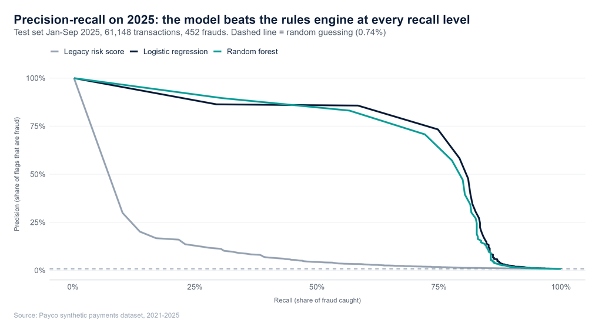

**Results.** The logistic regression reaches a PR-AUC of 0.71 on 2025, against 0.10 for the legacy risk score. Random guessing would score 0.007, the fraud rate itself. The random forest (0.70) and logistic regression (0.71) perform almost the same, so the gain comes from the engineered features, not from model complexity. The simpler, explainable model is a sensible choice for production.

### ROC curves

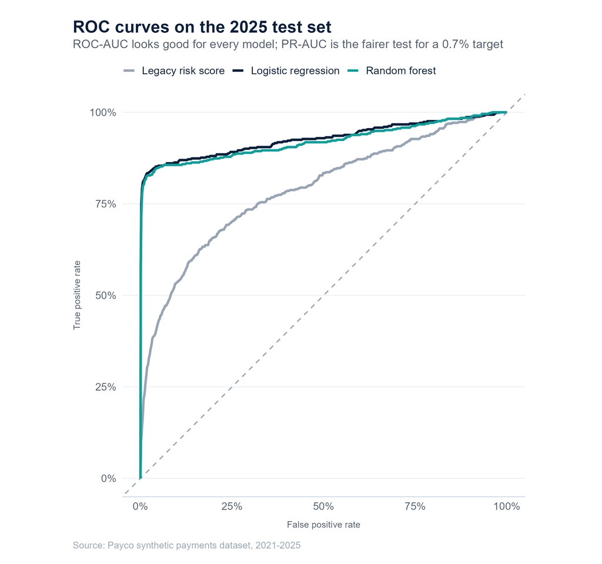

**Results.** ROC-AUC is 0.92 for the random forest, 0.93 for logistic regression and 0.79 for the legacy score. With fraud this rare, ROC-AUC flatters every model because true negatives dominate. That is why the precision-recall view above is the main measure.

### What drives the model

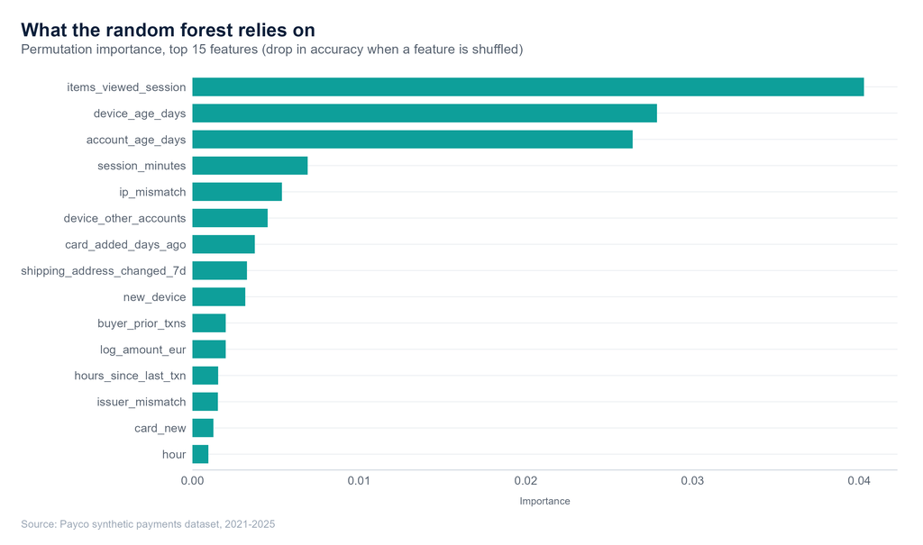

**Results.** The random forest relies most on items viewed in the session, device age and account age. These match the exploration on page 2, which is a good sign that the model has learned real behaviour and not noise. None of the top features are known only after the payment.

### Choosing the review threshold

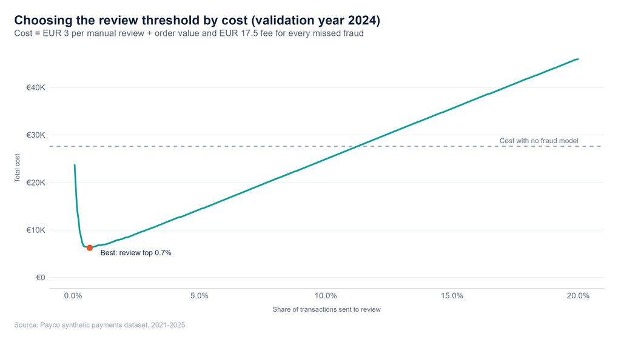

**Results.** The threshold was chosen on 2024, using a model trained on 2021-2023 so that the test year stays untouched. Reviewing a transaction costs EUR 3 and a missed fraud costs its order value plus a EUR 17.5 fee. The cheapest point flags 0.7% of transactions. Applied unchanged to 2025, it catches 78% of fraud (€41K of €47K), and 57% of flagged transactions are fraud.

### Lift by score decile

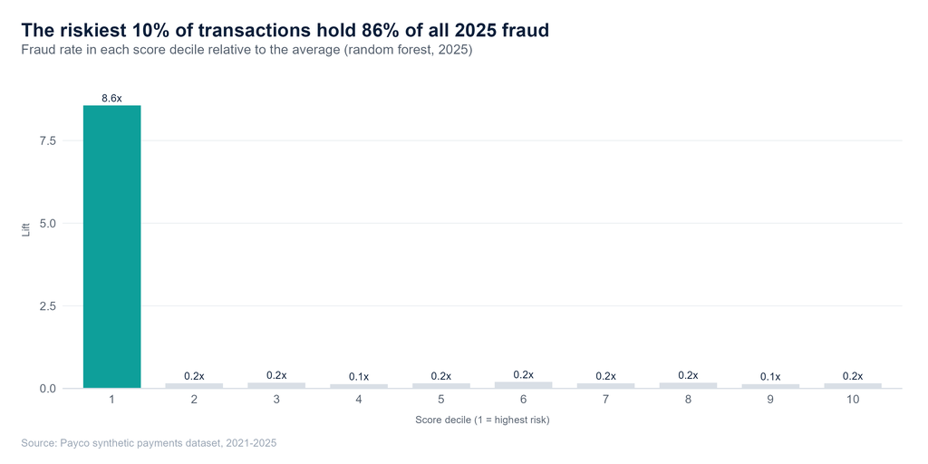

**Results.** The top 10% of transactions by model score hold 86% of all fraud in the test period, 8.6 times the average rate. The month with the weakest PR-AUC was April (0.66), so a monthly monitoring report should watch for drift during new fraud waves.

| Outcome at the chosen threshold, 2025 | Transactions |
| --- | --- |
| Fraud caught (true positive) | 351 |
| Legit flagged for review (false positive) | 261 |
| Fraud missed (false negative) | 101 |
| Legit approved (true negative) | 60,435 |

## 4. Payment failure

Why payments fail, how outages show up, and whether a failed attempt can be predicted before it is sent.

Failed attempts 2025

10.2%

-0.8 pp vs 2024

Technical error rate

0.38%

Failure model ROC-AUC

0.71

Logistic regression

Failure rate, riskiest 10%

31%

vs 2% in the safest 10%

### Failure rate by payment method

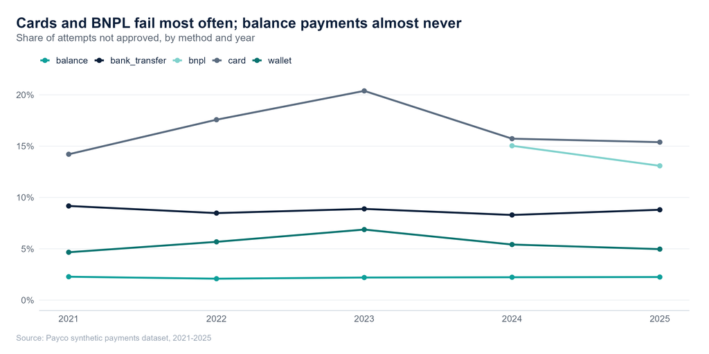

**Results.** In 2025, 15.4% of card attempts failed, against 5.0% for wallets and 13.1% for BNPL, where the provider runs its own credit check. Wallets fail less because the card is already tokenised and authenticated on the phone. Cards and wallets had their worst year in 2023, when stricter 3DS rules added friction.

### Decline reasons

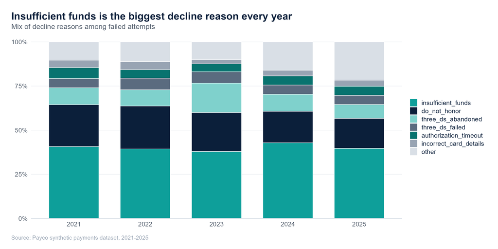

**Results.** Insufficient funds explains between 38% and 43% of failures each year. These are soft declines, so a retry later or with another method often works. 3DS abandonment grew in 2023, when step-up authentication was enforced more often.

### PSP outage, March 2023

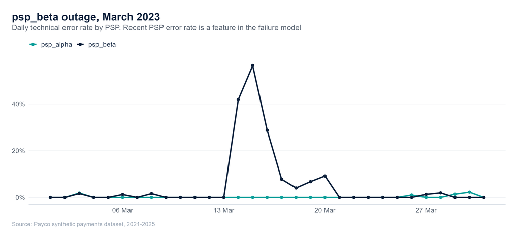

**Results.** On 15 March 2023 psp_beta returned errors on 56% of attempts, while psp_alpha averaged 0.2% that month. The failure model includes each PSP’s error rate in the previous hour, which lets it react to an outage while it is happening. In 2024 smart retry routing was added so that such errors are retried on another PSP.

### Month-end effect

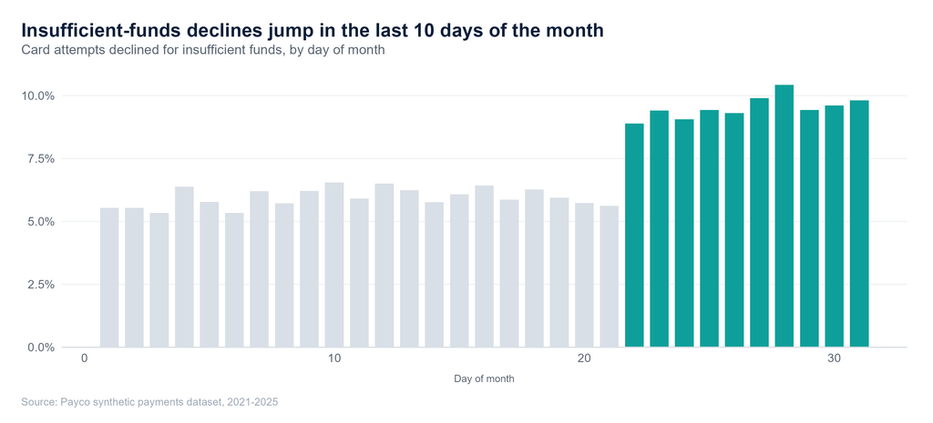

**Results.** From the 22nd of the month, insufficient-funds declines on cards are 1.6 times as common as earlier in the month, as balances run low before payday. Day of month is a simple, legitimate feature for the failure model.

### Failure model

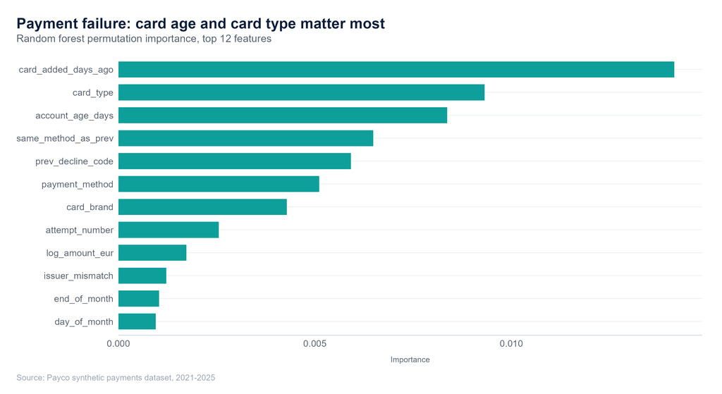

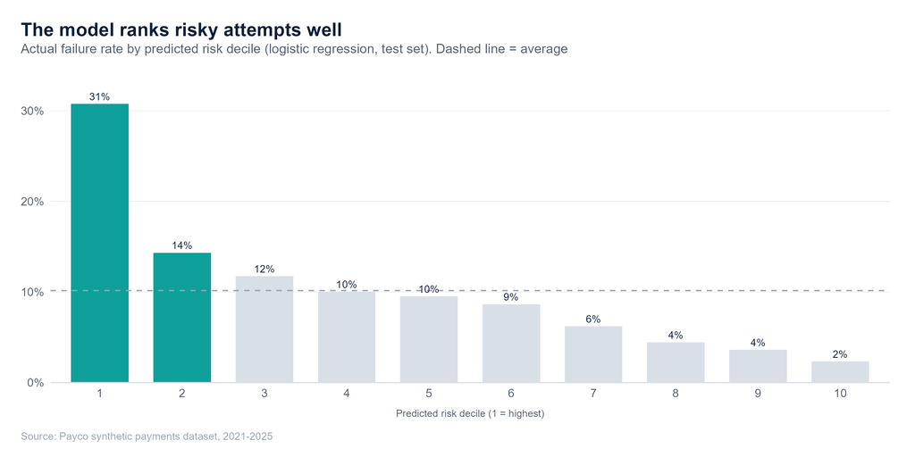

**Results.** On 2025 attempts, the logistic regression reaches ROC-AUC 0.71 and PR-AUC 0.30 (base rate 10.2%). The riskiest 10% of attempts fail 31% of the time, against 2% for the safest 10%. Failure is harder to predict than fraud because the issuer’s decision is mostly hidden from the merchant. Even so, the model can route risky attempts to a wallet prompt or a different PSP before they fail.

## 5. Buyer churn

Which active buyers will stop buying in the next 180 days? Trained on snapshots from mid-2023 to end-2024 and tested on buyers active on 30 June 2025.

Churn rate, test snapshot

42%

14,079 active buyers

Churn model ROC-AUC

0.75

Random forest

Churn, riskiest 10%

82%

vs 14% in the safest 10%

Training rows

44,465

4 snapshots

### Who churns

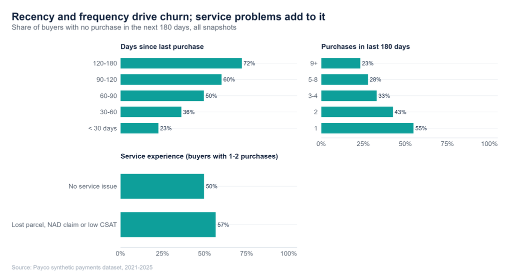

**Results.** Buyers whose last purchase was 120-180 days ago churn 72% of the time, against 23% for those who bought in the last month. Comparing buyers with similar activity (1-2 purchases), a lost parcel, not-as-described claim or low CSAT raises churn from 50% to 57%. Without that control the effect disappears, because frequent buyers hit more problems and also churn less. This is a Simpson’s paradox worth explaining in an interview.

### Churn model

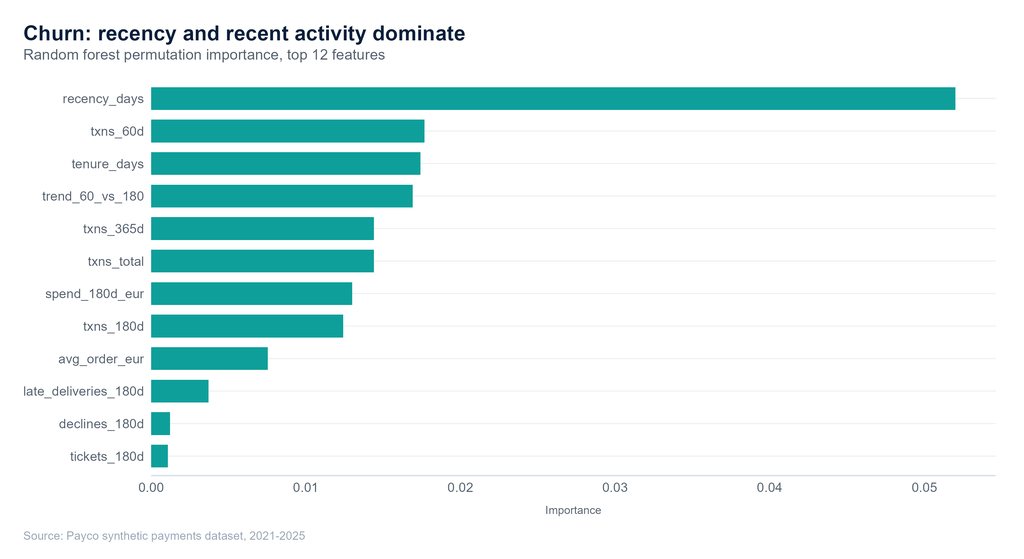

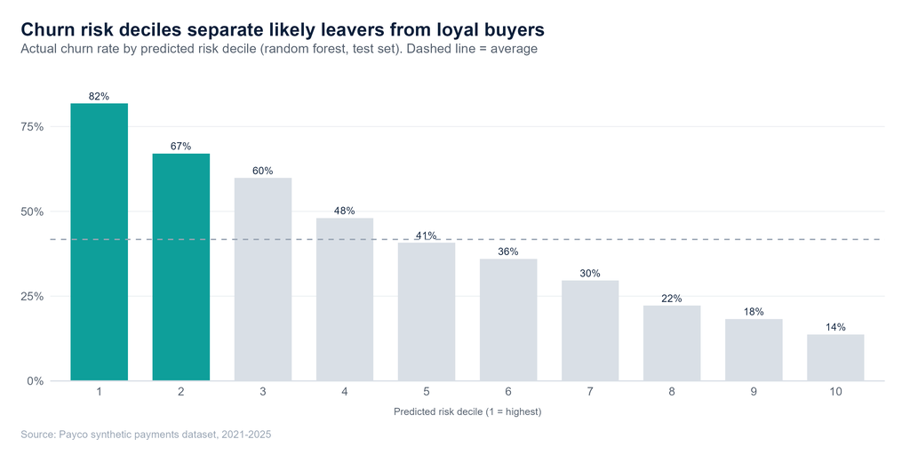

**Results.** The random forest reaches ROC-AUC 0.75 on the June 2025 snapshot. The top drivers are days since last purchase, purchases in the last 60 days and tenure: activity that is fading is the clearest warning. The riskiest decile churns 82% of the time and the safest 14%, which is enough to target a win-back campaign at buyers before they leave.

### Model comparison

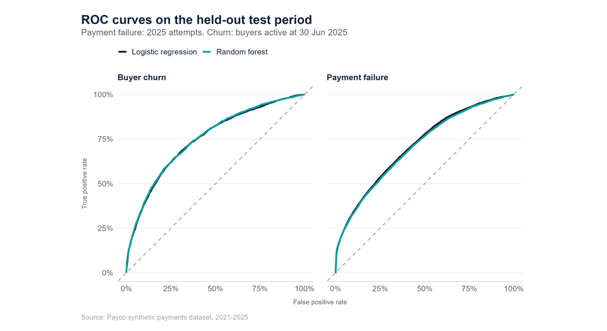

| Task | Model | ROC-AUC | PR-AUC | Base rate | Recall in top flagged |
| --- | --- | --- | --- | --- | --- |
| Fraud | Legacy risk score | 0.79 | 0.10 | 0.74% | 21% (top 1%) |
| Fraud | Logistic regression | 0.93 | 0.71 | 0.74% | 79% (top 1%) |
| Fraud | Random forest | 0.92 | 0.70 | 0.74% | 78% (top 1%) |
| Payment failure | Logistic regression | 0.71 | 0.30 | 10.16% | 30% (top 10%) |
| Payment failure | Random forest | 0.71 | 0.29 | 10.16% | 30% (top 10%) |
| Buyer churn | Logistic regression | 0.75 | 0.69 | 41.74% | 20% (top 10%) |
| Buyer churn | Random forest | 0.75 | 0.69 | 41.74% | 20% (top 10%) |

**Results.** Across all three tasks, logistic regression and the random forest end up close to each other. The time-aware, leakage-safe features matter more than the choice of algorithm. Fraud is the most predictable target. Payment failure is the hardest, because most of the decision sits with the card issuer.

Data: Payco synthetic payments dataset (fictional C2C marketplace), 2021-2025. Paid volume = order value of paid transactions in EUR at daily FX rates. Built with R, ggplot2, ranger and R Markdown.